# prob3 fe

## Generalization

#### When a machine learning model learns concepts that fit with given set of data(training data) and uses applies them to new data(test data) which are not part of training data refers to Generalization in Machine Learning

#### A good machine learning model should be able to generalize never seen data using what it learned from training data.

#### Underfitting and overfitting are two extreme cases of generalization. A good model must neither underfit nor overfit, it should at a optimal sweet spot between underfitting and overfitting.

## Overfitting

#### Overfitting happens when model fits the training data too well.This is caused to low bias and high variance between the model and the original data.

```python
import math
import numpy as np
import matplotlib.pyplot as plt
from numpy.linalg import inv
import matplotlib.patches as mpatches
import pandas as pd
```

#### For a one feature dataset, I have taken a 2D curve following the function f(x)=cos(x)+sin(x/2)

```python
def fun_y(x):
    return math.cos(x)+math.sin(x/2)
```

```python
trainx=np.arange(1,20,dtype='int64')
testx=np.arange(20,25,dtype='int64')
trainy=[fun_y(val) for val in trainx]
testy=[fun_y(val) for val in testx]
```

```python
print(trainy)
print(testy)
```

[output not shown]

Plot of traindata

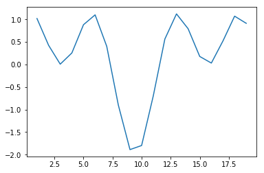

```python
plt.plot(trainx,trainy)
plt.show()
```

Function to Normalize data

```python
def norm(x):
    n=x-np.mean(x)
    n=n/np.std(x)
    return n
```

Below Function returns polynomial basis matrix for the given data x and polynomial degree n

```python
def polybasis(x,n):
    p=[]
    for i in range(n):
        p.append(x**i)
    return np.asarray(p).reshape([len(x),n])
```

```python
def error(y,pred):
    m=(pred-y)**2
    return sum(m)/len(y)
```

```python
def poly_regressorhelp(phi,y,l,n):
    I=np.eye(n)
    i=inv(l*I+np.dot(phi.T,phi))
    w=np.dot(i,np.dot(phi.T,y))
    return w
```

```python
def poly_regressor(x,y,test,testl,n):
    phi=polybasis(norm(x),n)
    l=0
    w=poly_regressorhelp(phi,y,l,n)
    trainpred=np.dot(phi,w)
    testpred=np.dot(polybasis(norm(test),n),w)
    trainerror=error(y,trainpred)
    testerror=error(testl,testpred)
    print('test error:',testerror)
    print('train error:',trainerror)
    t = x
    a = y
    b = trainpred
    plt.plot(t, a,'g-', label='true label') # plotting t, a separately
    plt.plot(t, b, 'r-',label='predicted label')
    #red_patch = mpatches.Patch(color='red', label='predicted label')
    #green_patch = mpatches.Patch(color='green', label='true label')
    #plt.legend(handles=[red_patch])
    plt.legend(loc='lower left')
    plt.show()
    if(testerror-trainerror>2):
        print('Overfitting occured')
        l_testerr=[]
        l_trainerr=[]
        lam=[0.01,0.1,1,10,100,500,1000,5000,10000]
        for i in lam:
            w=poly_regressorhelp(phi,y,i,n)
            trainpred=np.dot(phi,w)
            testpred=np.dot(polybasis(norm(test),n),w)
            l_trainerr.append(error(y,trainpred))
            l_testerr.append(error(testl,testpred))
        return [l_testerr,l_trainerr]
```

```
test error: 27.0442616915
train error: 0.422467883568
```

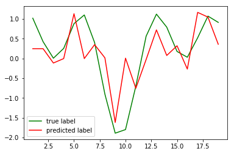

```
Overfitting occured
```

```python
result=poly_regressor(trainx,trainy,testx,testy,9)
```

### The function identified the overfitting as the test and train mean square errors are far apart. So the function tries to regularize the model with different lambda values and returns train and test accuracies for each lamda

```python
lam=np.array([0.01,0.1,1,10,100,500,1000,5000,10000])
testerr=np.array(result[0])
trainerr=np.array(result[1])
lam=lam.reshape([len(lam),1])
testerr=testerr.reshape([len(testerr),1])
trainerr=trainerr.reshape([len(trainerr),1])
z=np.concatenate((lam,trainerr,testerr),axis=1)
p=pd.DataFrame(z)
p.columns=['Lambda values','test accuracy','train accuracy']
p
```

[output not shown]

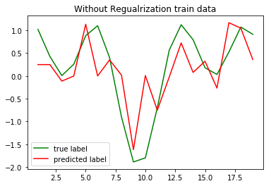

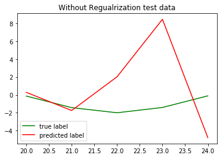

```python
phi=polybasis(norm(trainx),9)
wbest=poly_regressorhelp(phi,trainy,1000,9)
wori=poly_regressorhelp(phi,trainy,0,9)

tpred=np.dot(polybasis(norm(trainx),9),wori)
plt.title('Without Regualrization train data')
plt.plot(trainx,trainy,'g-', label='true label') # plotting t, a separately
plt.plot(trainx,tpred, 'r-',label='predicted label')
plt.legend(loc='lower left')
plt.show()

pred=np.dot(polybasis(norm(testx),9),wori)
plt.title('Without Regualrization test data')
plt.plot(testx, testy,'g-', label='true label') # plotting t, a separately
plt.plot(testx, pred, 'r-',label='predicted label')
plt.legend(loc='lower left')
plt.show()
```

### For the train data , the red curve which is prediction curve fitted well with the green curve which is original curve. This is overfitting

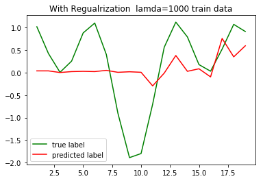

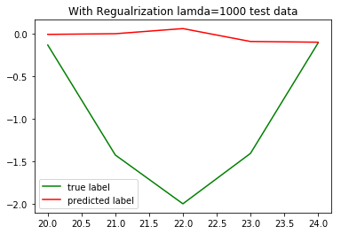

```python
tpredbest=np.dot(polybasis(norm(trainx),9),wbest)
plt.title('With Regualrization  lamda=1000 train data')
plt.plot(trainx,trainy,'g-', label='true label') # plotting t, a separately
plt.plot(trainx,tpredbest, 'r-',label='predicted label')
plt.legend(loc='lower left')
plt.show()

tepredbest=np.dot(polybasis(norm(testx),9),wbest)
plt.title('With Regualrization lamda=1000 test data')
plt.plot(testx, testy,'g-', label='true label') # plotting t, a separately
plt.plot(testx, tepredbest, 'r-',label='predicted label')
plt.legend(loc='lower left')
plt.show()
```

### For the train data , the red curve which is prediction curve did not fit well with the green curve which is original curve . So overfitting is avoided here

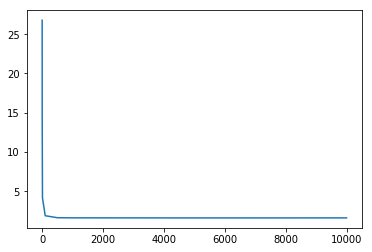

```python
plt.plot(lam,testerr)
plt.show()
```

### As lambda value increases , the mean square error(MSE) decreases and reaches to a point where the decrease in MSE is negligible